# Supplement to ‘Opportunity for verbalization does not improve visual change detection performance: A state-trace analysis’

Richard D. Morey and Florian Sense

1 May 2015

# The study

## Download

A PDF of the paper can be downloaded here.

## Abstract

> Experiments suggest that there is a strong tendency to verbally recode visually-presented information, and that in some cases verbal recoding can boost memory performance. According to multi-component models of working memory, memory performance is increased because task-relevant information is maintained in two codes. The possibility of dual encoding is problematic if the goal is to measure capacity for visual information exclusively. This is why articulatory suppression is typically used with visual change detection tasks specifically to prevent verbalization of visual stimuli. We present evidence from a large experiment that suggests that articulatory suppression has no discernable effect on performance in a visual change-detection task. Neither a descriptive nor a state-trace analysis revealed any complex relationship between suppression, presentation type, and performance. There is no evidence that verbal recoding was a strategy used by the participants in this task. We conclude that in typical visual change detection experiments, pre-cautionary articulatory suppression is unnecessary.

# Data

```r
source('intNormal.R') # for approximation to integral
# source('http://openmx.psyc.virginia.edu/getOpenMx.R')
library('OpenMx')
```

```r
library('gtools')
library('xtable')
plotRestricted = TRUE
loadSamples = TRUE
rand.seed = 595
set.seed(rand.seed)
loadSamples = loadSamples * plotRestricted
```

## Load and clean the data

The raw data is contained in the `combined_dataset.csv` file. We load the file and create meaningful names for the factors in the data set.

```r
data <- read.csv("combined_dataset.csv", stringsAsFactors = FALSE)

data$silent = factor(data$silent)
levels(data$silent) = c("articulate","silent")

data$sequential = factor(data$sequential)
levels(data$sequential) = c("simultaneous","sequential")

data$change = factor(data$change)
levels(data$change) = c("same","change")


data$subjNumber = factor(data$subjNumber)
data$setSize = factor(data$setSize)

data$blocknum = ((data$session-1)*504 + (data$trial-1))%/%252 + 1
```

We first remove trials for which the response time is missing.

```r
# What proportion of trials?
mean(is.na(data$RT))
```

```
## [1] 0.001045689
```

```r
data = data[!is.na(data$RT),]
```

And now we get rid of short and long response times (short are those faster than 200 ms and long are those slower than 3 seconds).

```r
1-mean(data$RT>200 & data$RT<3000) # What proportion of trials?
```

```
## [1] 0.02045253
```

```r
data = data[data$RT>200 & data$RT<3000, ]
```

## Data tidying

We now compute summary statistics for each participant by condition combination.

```r
# Correct trials for all combinations of conditions and participants
corrects = tapply(data$CResp,list(data$subjNumber,data$setSize,data$silent,data$sequential,data$change),sum)

# Total number of trials
Ntotal = table(data$subjNumber,data$setSize,data$silent,data$sequential,data$change)

# Convert tables to data frames for convenience
correctsDF = as.data.frame.table(corrects)
NtotalDF = as.data.frame.table(Ntotal)

# Check to make sure they line up
if(  all(correctsDF[,1:5] == NtotalDF[,1:5]) ){
  correctsDF$N = NtotalDF$Freq
  colnames(correctsDF) = c("sub","ss","art","seq","chg","cor","N")
}else{
  stop("Could not merge data sets.")
}

# Compute estimates of probabilities and corresponding standard errors
correctsDF$phat = (correctsDF$cor + 1) / (correctsDF$N + 2)
correctsDF$stdErr = sqrt(correctsDF$phat * (1 - correctsDF$phat) / (correctsDF$N + 2))

chg = correctsDF[correctsDF$chg=="change",]
sme = correctsDF[correctsDF$chg=="same",]

# Check to make sure they line up
if(  all(sme[,1:4] == chg[,1:4]) ){
  combinedDat = sme[,1:4]
  # hits minus false alarms
  combinedDat$d = chg$phat + sme$phat - 1
  combinedDat$stdErr = sqrt(sme$stdErr^2 + chg$stdErr^2)
}else{
  stop("Could not merge same and change.")
}
```

# Figures and analyses

## Figure 1: Experimental paradigm

Figure 1 was created in OmniGraffle Professional. The `.graffle` file as well as the exported `.pdf` are located in `./figures/`.

## Table 1: Descriptive statistics for the different conditions

```r
chg.mns = with(chg,tapply(phat, list(ss, art, seq), mean))
chg.sds = with(chg,tapply(phat, list(ss, art, seq), sd))

sme.mns = 1-with(sme,tapply(phat, list(ss, art, seq), mean))
sme.sds = with(sme,tapply(phat, list(ss, art, seq), sd))

tbl.data <- cbind( as.data.frame(chg.mns), as.data.frame(sme.mns) )
table1 <- xtable(tbl.data, caption="Mean hit and false alarm rates for all conditions across all participants.", label="tab:descriptiveStats")
print(table1) # produces the template for the LaTeX syntax used in the paper.
```

```
## % latex table generated in R 3.1.2 by xtable 1.7-4 package
## % Tue Aug  4 11:28:59 2015
## \begin{table}[ht]
## \centering
## \begin{tabular}{rrrrrrrrr}
##   \hline
##  & articulate.simultaneous & silent.simultaneous & articulate.sequential & silent.sequential & articulate.simultaneous & silent.simultaneous & articulate.sequential & silent.sequential \\
##   \hline
## 2 & 0.95 & 0.95 & 0.94 & 0.94 & 0.08 & 0.06 & 0.11 & 0.07 \\
##   4 & 0.84 & 0.88 & 0.82 & 0.82 & 0.25 & 0.22 & 0.31 & 0.26 \\
##   8 & 0.72 & 0.70 & 0.70 & 0.70 & 0.41 & 0.39 & 0.41 & 0.42 \\
##    \hline
## \end{tabular}
## \caption{Mean hit and false alarm rates for all conditions across all participants.}
## \label{tab:descriptiveStats}
## \end{table}
```

## Figure 2: Descriptive statistics for the different conditions

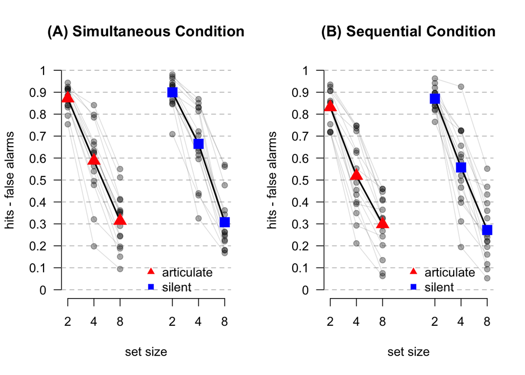

```r
par(mfrow = c( 1, 2), las=1)

for(cond in c('simultaneous', 'sequential')) {

  plot(NA, ylim=c(0, 1), xlim=c(1, 7), ylab='hits - false alarms', xlab='set size', main=paste(ifelse(cond == 'sequential', '(B) Sequential', '(A) Simultaneous'), 'Condition'), axes=FALSE)
  axis(1, at=c(1:3, 5:7), labels=rep(c(2,4,8), 2), mgp=c(1, 1, 0))
  axis(2, at=seq(0, 1, .1), labels=seq(0, 1, .1))
  abline(h=seq(0, 1, .1), col='gray', lty=2)

  # one line per pp
  for(s in unique(combinedDat$sub)) {
    y1 <- combinedDat$d[combinedDat$sub == s & combinedDat$art == 'articulate' & combinedDat$seq == cond]
    y2 <- combinedDat$d[combinedDat$sub == s & combinedDat$art == 'silent' & combinedDat$seq == cond]
    lines(x=c(1:3), y=y1, col='#00000022')
    lines(x=c(5:7), y=y2, col='#00000022')
    points(x=c(1:3, 5:7), y=c(y1, y2), col='#00000055', pch=19)
  }

  # group means as symbols
  gM <- aggregate(d ~ ss + seq + art, combinedDat, mean)
  gM <- gM$d[gM$seq == cond]
  lines(x=c(1:3), y=gM[1:3], col='#000000', lwd=2)
  lines(x=c(5:7), y=gM[4:6], col='#000000', lwd=2)
  points(x=c(1:3, 5:7), y=gM, col=rep(c('#FF0000', '#0000FF'), each=3), pch=rep(c(17, 15), each=3), cex=1.8)

  # add a legend
  legend(x=3.75, y=.15, legend=c('articulate', 'silent'), col=c('#FF0000', '#0000FF'), pch=c(17,15), bty='n')
}
```

## Figure 3A: Sequential silent advantage vs. simultaneous silent advantage

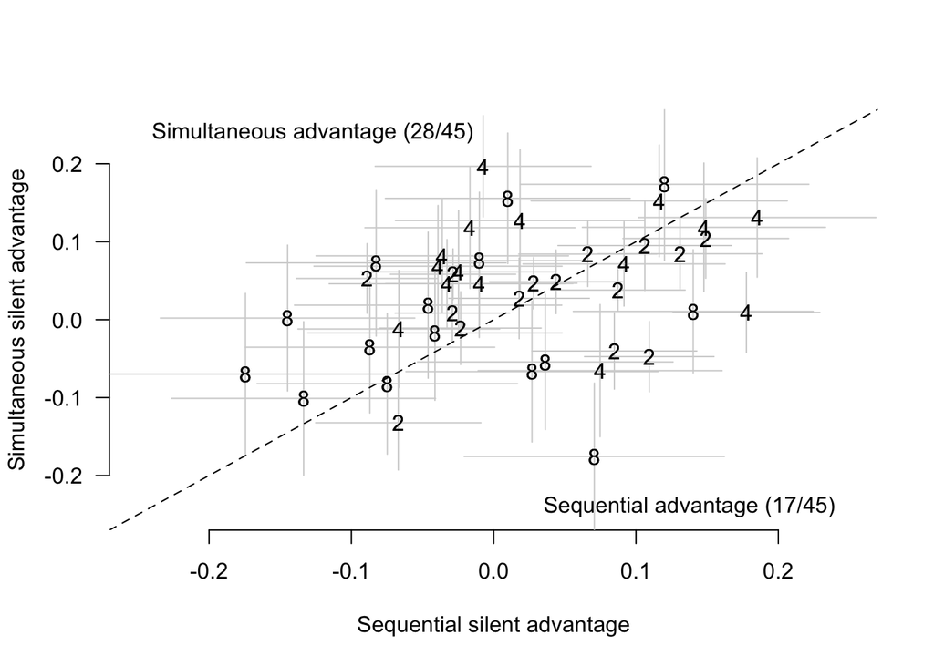

```r
eff.est = combinedDat[combinedDat$art=="silent","d"] - combinedDat[combinedDat$art=="articulate","d"]
eff.se = sqrt(combinedDat[combinedDat$art=="silent","stdErr"]^2 + combinedDat[combinedDat$art=="articulate","stdErr"]^2)

effDF = cbind(combinedDat[combinedDat$art=="silent",-c(3,5,6)],eff = eff.est, stdErr = eff.se)

par(las=1, bty="n")
plot(effDF[effDF$seq == "sequential","eff"], effDF[effDF$seq == "simultaneous","eff"],
     ylim = c(-.25,.25), xlim = c(-.25,.25), ylab = "Simultaneous silent advantage",
     xlab = "Sequential silent advantage", pch = as.character(effDF[effDF$seq == "sequential","ss"]))

segments(effDF[effDF$seq == "sequential","eff"] - effDF[effDF$seq == "sequential","stdErr"],
       effDF[effDF$seq == "simultaneous","eff"],
       effDF[effDF$seq == "sequential","eff"] + effDF[effDF$seq == "sequential","stdErr"],
       effDF[effDF$seq == "simultaneous","eff"],
       col="lightgray")

segments(effDF[effDF$seq == "sequential","eff"],
         effDF[effDF$seq == "simultaneous","eff"] - effDF[effDF$seq == "simultaneous","stdErr"],
         effDF[effDF$seq == "sequential","eff"],
         effDF[effDF$seq == "simultaneous","eff"] + effDF[effDF$seq == "simultaneous","stdErr"],
         col="lightgray")

points(effDF[effDF$seq == "sequential","eff"], effDF[effDF$seq == "simultaneous","eff"],
 pch = as.character(effDF[effDF$seq == "sequential","ss"]))
abline(0,1, lty=2)
text(-.24,.24,adj=0,"Simultaneous advantage (28/45)")
text(.24,-.24,adj=1,"Sequential advantage (17/45)")
```

```r
sum((effDF[effDF$seq == "sequential","eff"] - effDF[effDF$seq == "simultaneous","eff"]) > 0)
```

```
## [1] 17
```

```r
nrow(effDF[effDF$seq == "sequential",])
```

```
## [1] 45
```

## Figure 3B: Target effect across time

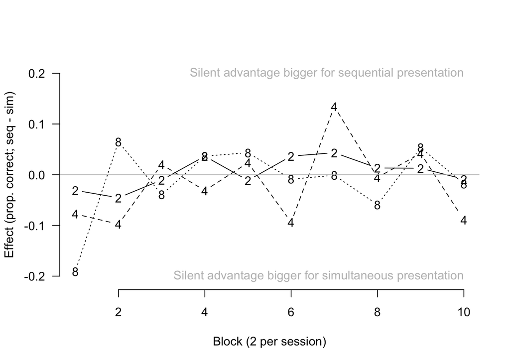

```r
corr.by.block = with(data,tapply(CResp,list(blocknum,setSize,silent,sequential),mean))
adv.for.silent = corr.by.block[,,"silent",] - corr.by.block[,,"articulate",]
effect.by.pres = adv.for.silent[,,"sequential"] - adv.for.silent[,,"simultaneous"]

par(las=1, bty="n")
matplot(effect.by.pres, ylab="Effect (prop. correct; seq - sim)",
        xlab="Block (2 per session)",ty='b',pch=c("2","4","8"),ylim=c(-.21,.21), col=1)
abline(h=0,col="gray")
text(10,.2,"Silent advantage bigger for sequential presentation",adj=1, col="gray")
text(10,-.2,"Silent advantage bigger for simultaneous presentation",adj=1, col="gray")
```

## Figure 4: Individual state-trace plots and Bayes factors

Make plots and compute Bayes factors.

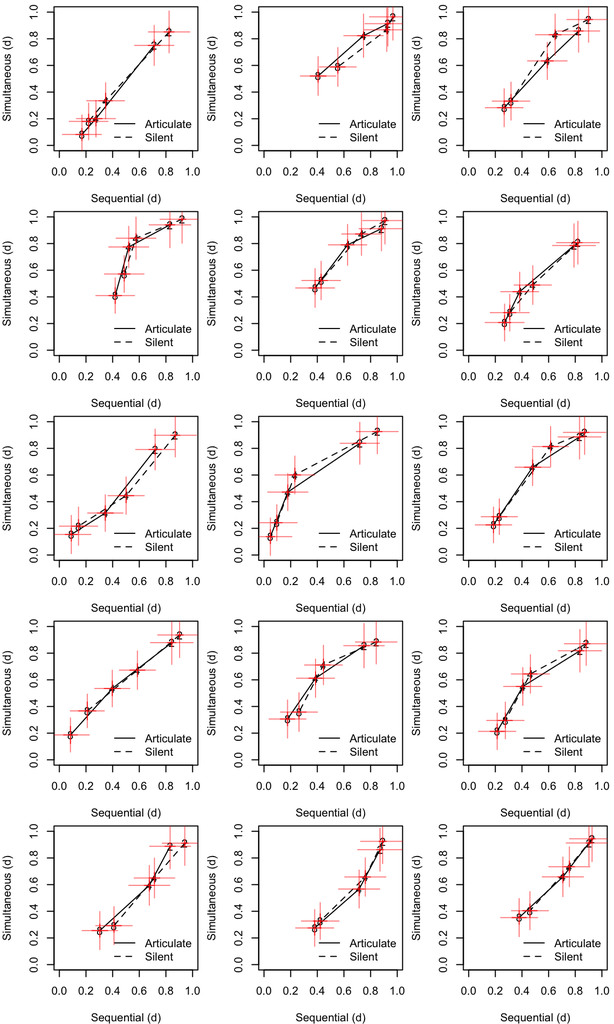

```r
# Reserve object for Bayes factors
BF = 1:length(unique(combinedDat$sub))
names(BF) = unique(combinedDat$sub)
bf.ord = order(read.table(file="BFs.txt"))

subs = unique(combinedDat$sub)[bf.ord]

par(mfrow=c(5,3), mar=c(4,4,.5,.5))

sub.samples = list()
if(loadSamples) load("samples.Rda")

# Do each subject analysis separately
for(sub in subs){
  datSub = combinedDat[combinedDat$sub==sub,]

  # set up for normal approximation to posterior

  # means
  simMu = datSub$d[1:6]
  seqMu = datSub$d[1:6 + 6]

  # standard deviations
  simStdErr = datSub$stdErr[1:6]
  seqStdErr = datSub$stdErr[1:6 + 6]

  # labels (for order restrictions)
  simLab = paste(datSub$ss[1:6],datSub$art[1:6],sep=".")
  seqLab = paste(datSub$ss[1:6 + 6],datSub$art[1:6 + 6],sep=".")

  # Determine all permutations
  perms = permutations(6,6)
  # Restrict to permutations that make sense
  accOrds = apply(perms,1,checkOrdering,labs=simLab)
  ords = perms[accOrds,]

  # Compute probabilities of orderings for seq and simulat
  probsSim = apply(ords,1,post.prob.order,mus=simMu,sig2=simStdErr^2)
  probsSeq = apply(ords,1,post.prob.order,mus=seqMu,sig2=seqStdErr^2)
  names(probsSim) = names(probsSeq)= apply(ords,1,paste,collapse=',')

  # Renormalize
  probsSim = probsSim / sum(probsSim)
  probsSeq = probsSeq / sum(probsSeq)

  # Assume independence
  jointOrderProbs = outer(probsSim,probsSeq)

  # ignore non overlapping model
  jointOrderProbs[1,1] = NA
  jointOrderProbs = jointOrderProbs/sum(jointOrderProbs,na.rm=TRUE)

  #prob monotone (diagonal)
  probMono = sum(diag(jointOrderProbs),na.rm=TRUE)
  probNonMono = 1 - probMono

  priorProbMono = (dim(jointOrderProbs)[1]-1) / (length(jointOrderProbs)-1)


  # Bayes factor is posterior odds over prior odds
  BF[sub] = (probMono / probNonMono) / (priorProbMono / (1-priorProbMono))



  if(loadSamples){
    samples.sim = sub.samples[[sub]][["sim"]]
    samples.seq = sub.samples[[sub]][["seq"]]
  }else if(plotRestricted){
    sufficient = FALSE
    samples.sim = NULL
    while(!sufficient){
      samples.sim = rbind(
        samples.sim,
        restrict.samples.mean(simMu,simStdErr,simLab,M=10000,articRestrict=TRUE))
      if(nrow(samples.sim)>5000) sufficient = TRUE
    }

    sufficient = FALSE
    samples.seq = NULL
    while(!sufficient){
      samples.seq = rbind(
        samples.seq,
        restrict.samples.mean(seqMu,seqStdErr,simLab,M=10000,articRestrict=TRUE))
      if(nrow(samples.seq)>5000) sufficient = TRUE
    }
  }

  if(plotRestricted){
    my.d = c(colMeans(samples.sim),colMeans(samples.seq))
    my.serr = c(apply(samples.sim,2,sd),apply(samples.seq,2,sd))
  }else{
    my.d = datSub$d
    my.serr = datSub$stdErr
  }


    # Plot
  plot(my.d[1:6 + 6],my.d[1:6],pch=as.character(datSub$ss[1:6]),main="",xlab="Sequential (d)",ylab="Simultaneous (d)",ylim=c(0,1),xlim=c(0,1),asp=TRUE)
  lines(my.d[1:3 + 6],my.d[1:3],lty=1)
  lines(my.d[1:3 + 3 + 6],my.d[1:3 + 3],lty=2)
  arrows(my.d[1:6 + 6]-my.serr[1:6 + 6],my.d[1:6],my.d[1:6 + 6] + my.serr[1:6 + 6], my.d[1:6],code=3,angle=0,col=rgb(1,0,0,.5))
   arrows(my.d[1:6 + 6],my.d[1:6]-my.serr[1:6],my.d[1:6 + 6], my.d[1:6]+my.serr[1:6],code=3,angle=0,col=rgb(1,0,0,.5))

  legend("bottomright",legend=c("Articulate","Silent"),lty=1:2, bty='n')
  }
```

```r
  if(plotRestricted)
    sub.samples[[sub]] = list(seq = samples.seq, sim = samples.sim)


if(plotRestricted)
  save("sub.samples", file="samples.Rda")
```

```r
# What are the valid orders?
t(apply(ords,1,function(row,labs) labs[row],labs=simLab))
```

```
##      [,1]           [,2]           [,3]           [,4]
## [1,] "8.articulate" "4.articulate" "2.articulate" "8.silent"
## [2,] "8.articulate" "4.articulate" "8.silent"     "2.articulate"
## [3,] "8.articulate" "4.articulate" "8.silent"     "4.silent"
## [4,] "8.articulate" "8.silent"     "4.articulate" "2.articulate"
## [5,] "8.articulate" "8.silent"     "4.articulate" "4.silent"
##      [,5]           [,6]
## [1,] "4.silent"     "2.silent"
## [2,] "4.silent"     "2.silent"
## [3,] "2.articulate" "2.silent"
## [4,] "4.silent"     "2.silent"
## [5,] "2.articulate" "2.silent"
```

```r
# write.table(file="BFs.txt",BF) # this is how the file was created
```

### More on Bayes factors

It must be noted that the Bayes factors described in this paper are Bayes factors favoring the monotonicity of the observed points. Technically, the null hypothesis in state-trace analysis is that all possible points are so ordered, but testing this hypothesis would require much stronger parametric assumptions. The current approach trades strong assumptions for weaker conclusions.

An additional plot, showing only the Bayes factors (not included in the paper).

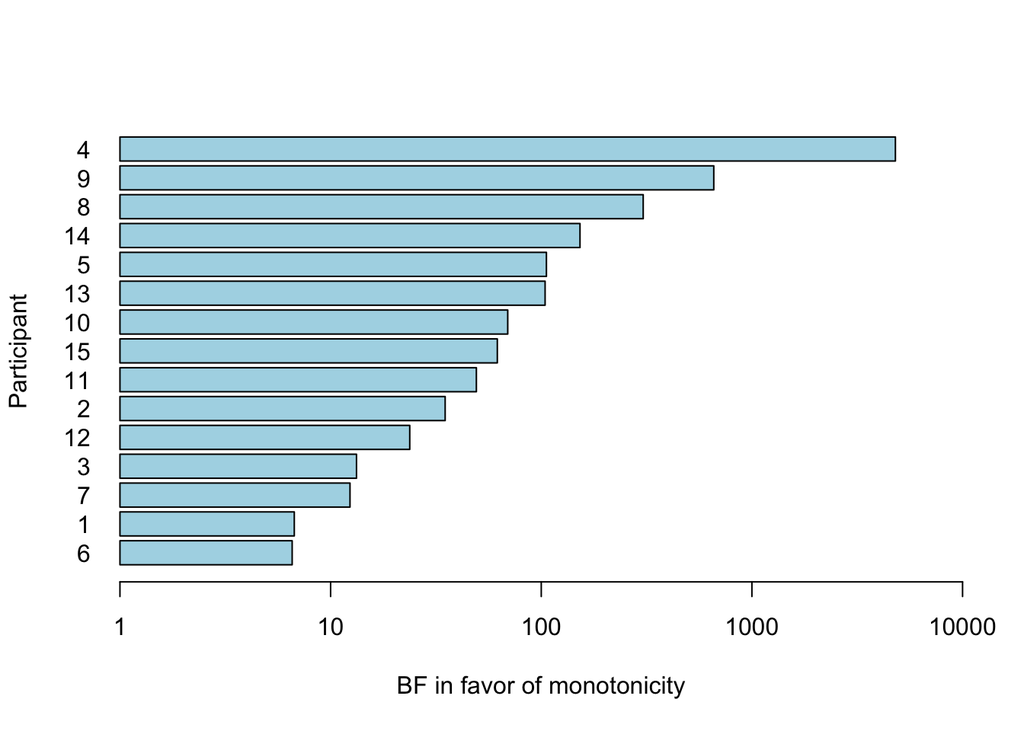

```r
BF = sort(BF)
newNum = match(names(BF),unique(data$subjNumber))
par(las=1)
q = barplot(BF,horiz=TRUE,axes=FALSE,xlab="BF in favor of monotonicity",ylab="Participant",log="x",names.arg=rep("",length(BF)),col="lightblue",xlim=c(1,10000))
axis(1)
axis(2,at=q,lab=newNum,tick=FALSE)
```